# Confidence Intervals

## Confidence intervals measure the uncertainty in a parameter estimate

- Analytical
  - Approximate calculation relying on 2 \(\times\) SE
  - Exact calculate using a critical *t*-value
- Maximum Likelihood
  - Iterate over possible parameter values
  - Identify the range of likelihoods summing to 0.95
- Bayesian Credible Intervals
  - Region including highest 95% of posterior density

## Calculating exact confidence intervals

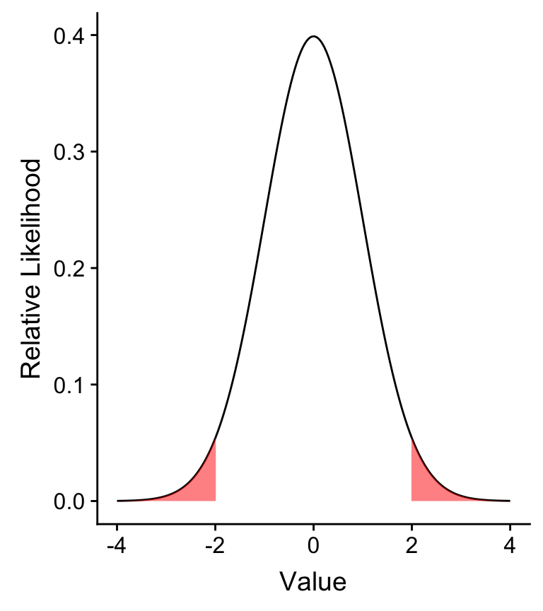

- 2 is an approximation
- True value is ~1.96 for a normal distribution (infinite sample size/true population distribution)
- Samples rely on the *t*-distribution
- Increase width of CI for smaller sample size

## Calculating exact confidence intervals

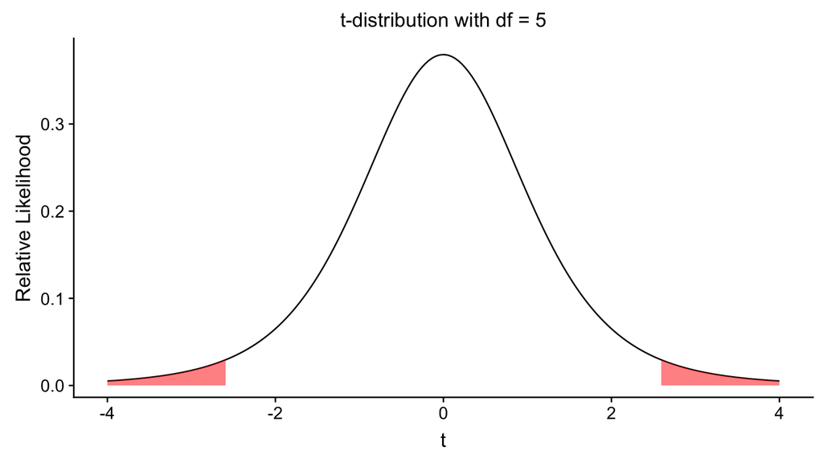

Need the critical value that marks the 2.5% cutoff at either end.

## Calculating exact confidence intervals

Multiply the SE by the *t*-value encompassing 95% for a *t* distribution with a given # of degrees of freedom (e.g., a given sample size).

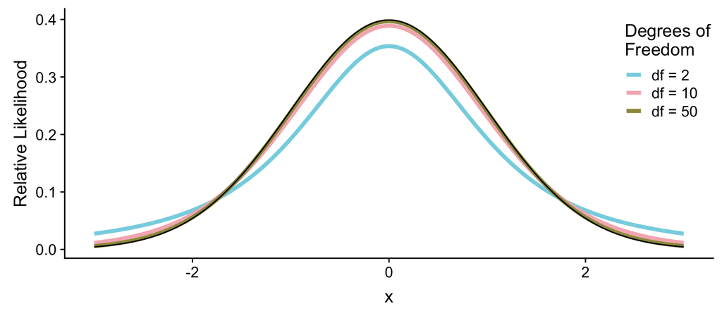

## Calculating exact confidence intervals

```r
qt(0.975, 10 - 1)
```

```
## [1] 2.262157
```

```r
qt(0.975, 100 - 1)
```

```
## [1] 1.984217
```

```r
qt(0.975, 1000000000 - 1)
```

```
## [1] 1.959964
```

```r
qnorm(0.975, 0, 1)
```

```
## [1] 1.959964
```

## 95% CI for snake undulation (*n* = 8)

```r
undulation_rate <- c(0.9, 1.2, 1.2, 1.3, 1.4, 1.4, 1.6, 2.0)
undulation_mean <- mean(undulation_rate)
undulation_SEM <- sd(undulation_rate) / sqrt(length(undulation_rate))
(crit <- qt(0.025, df = 7, lower.tail = FALSE))
```

```
## [1] 2.364624
```

```r
lower <- undulation_mean - crit * undulation_SEM
upper <- undulation_mean + crit * undulation_SEM
c(lower, undulation_mean, upper)
```

```
## [1] 1.104098 1.375000 1.645902
```

## Bayesian Credible Intervals

- Summarize the posterior distributions of Bayesian analyses
- Range of the most plausible estimates given the model
- XX% highest density interval
- XX% quantile

## MCMC sampling

- Most general way to do Bayesian inference
- No complicated integrals
- Requires time and computational power

## MCMC sampling

```r
fm <- map2stan(
  alist(
    undulation_rate ~ dnorm(mu, sigma),
    mu ~ cauchy(0, 5),
    sigma ~ cauchy(0, 5)
  ),
  data = list(undulation_rate = undulation_rate),
  iter = 1e4,
  warmup = 1e3,
  WAIC = FALSE
)
```

## MCMC sampling output

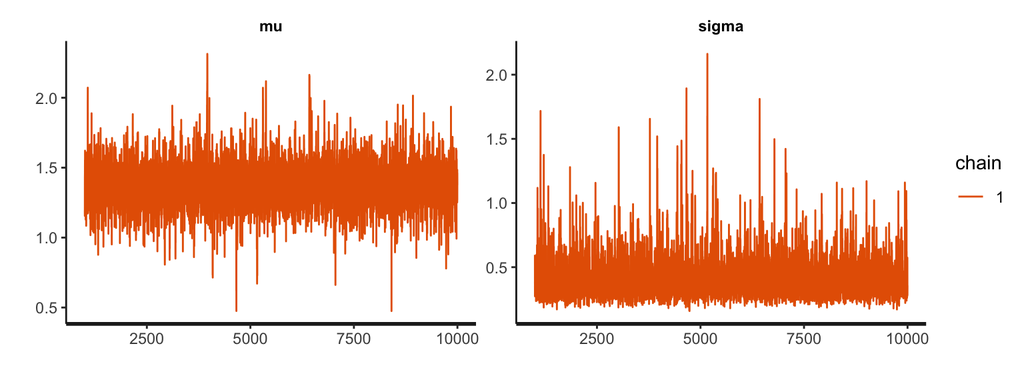

## MCMC sampling

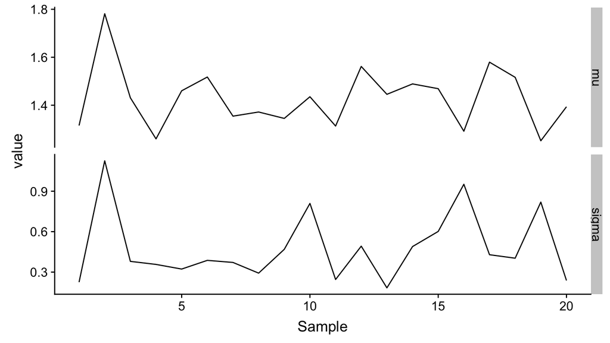

## MCMC method

- Current position (has a likelihood)
- Propose a change (has a likelihood)
- Move to proposed values with probability proportional to their ratio
- "Bad" jumps are possible with some non-zero probability

## Current estimates

Sample 1:

```r
post[1, ]
```

```
##         mu     sigma Sample
## 1 1.315388 0.2253835      1
```

```r
rel_liks <- dnorm(undulation_rate, mean = post$mu[1],
                  sd = post$sigma[1], log = TRUE)
(current_ll <- sum(rel_liks))
```

```
## [1] -2.946292
```

## Proposed estimates

```r
mu_prop <- 1.37
sigma_prop <- 0.3
rel_liks <- dnorm(undulation_rate, mean = mu_prop,
                  sd = sigma_prop, log = TRUE)
(proposed_ll <- sum(rel_liks))
```

```
## [1] -1.80417
```

```r
exp(proposed_ll) / exp(current_ll)
```

```
## [1] 3.133409
```

Ratio > 1, so definitely move.

```r
current_ll <- proposed_ll
```

## Proposed estimates

```r
proposed_ll <- sum(dnorm(undulation_rate,
                         mean = 1.5, sd = 0.22,
                         log = TRUE))
exp(proposed_ll) / exp(current_ll)
```

```
## [1] 0.09840992
```

Ratio < 1, so the probability of moving is equal the ratio (here ~10%).

- This allows moves to lower likelihood estimates (as long as the probability of moving is not too small).

## MCMC sampling

The samples will oscillate around the most probable estimates, in proportion to their probabilities.

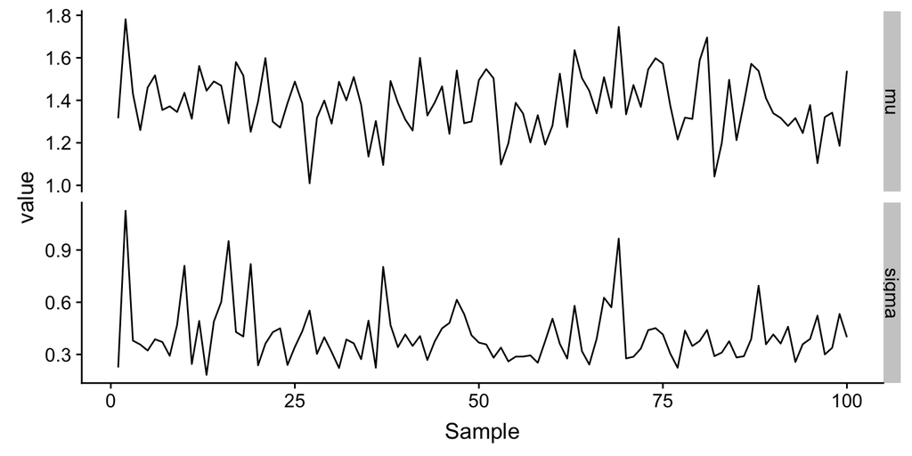

## Bayesian credible intervals

Posterior distribution of mean undulation, given, the model (including priors) and data:

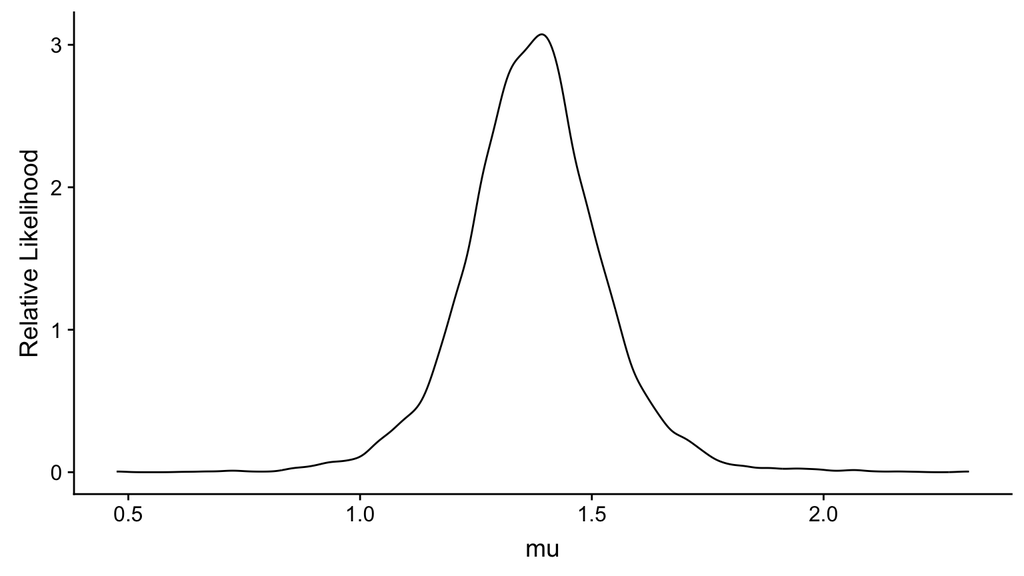

## Bayesian credible intervals

95% Highest density interval is the most probable location for the mean (given the model and the data).

```
##    |0.95    0.95|
## 1.060443 1.669414
```

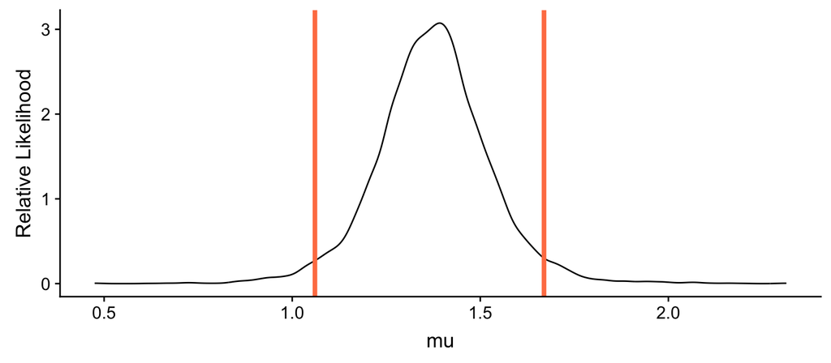

## Interpreting intervals

Frequentist interval: 1.1 – 1.65

- Future similar experiments and samples
- Does not indicate the probability of the parameter

Bayesian interval: 1.06 – 1.67

- These data and this model
- Relative probability within a region

## Quiz 06-3

Complete quiz 06-3.

Move on to Lecture 06-4.